# Cyclist Bike_Share Analysis

Sebastine Amede

2023-05-22

# Cyclist Bike_Share Analysis

This is an in-depth analysis on how Annual members and casual members use Cyclist differently.

- **Background:** I am a junior data analyst at Cyclists, a bike sharing company, and that the company’s success relies on maximizing the number of annual memberships. The objective of this analysis, is to understand how annual members and casual riders use *Cyclist bikes* differently.
- **Business Task:** The task at hand is about understanding the different bike usage patterns of the casual members riders and the annual member riders, in order to create a new strategy to convert casual members to annual members with the aim of maximizing profit for the company.
- **Data Sources:** For this analysis i have been provided with relevant dataset from the company and i would be making use a 12months data from 2022 for this analysis. such as cyclist_data_01 (January dataset), cyclist_data_02 (February dataset), and so on, which contain information about rides, ride duration, stations, and membership types.
- **Importance of the Analysis:** The insights gained from understanding the behavior of annual members and casual riders can help in developing targeted marketing campaigns and improving the company’s overall profitability
- **Structure of the Report:** I will be documenting the data cleaning and manipulation steps, provide a summary of the analysis, present key findings, share supporting visualizations, and conclude with actionable recommendations.
- **Tools Used** Data cleaning, Wrangling, Preparing, Analyzing and Visualization will be done using R programming Language on R-Studio.

```r
options(repos = "https://cran.rstudio.com/")
```

# Starting off analysis by installing and loading required packages

```r
install.packages("readr")
library(readr)
```

```r
cyclist_data_01 <- read_csv("~/Downloads/2022 cyclist data/cyclist_data_01.csv") #loading january data
cyclist_data_02 <- read_csv("~/Downloads/2022 cyclist data/cyclist_data_02.csv") #loading February data
cyclist_data_03 <- read_csv("~/Downloads/2022 cyclist data/cyclist_data_03.csv") #loading March data
cyclist_data_04 <- read_csv("~/Downloads/2022 cyclist data/cyclist_data_04.csv") #loading April data
cyclist_data_05 <- read_csv("~/Downloads/2022 cyclist data/cyclist_data_05.csv") #loading May data
cyclist_data_06 <- read_csv("~/Downloads/2022 cyclist data/cyclist_data_06.csv") #loading June data
cyclist_data_07 <- read_csv("~/Downloads/2022 cyclist data/cyclist_data_07.csv") #loading July data
cyclist_data_08 <- read_csv("~/Downloads/2022 cyclist data/cyclist_data_08.csv") #loading August data
cyclist_data_09 <- read_csv("~/Downloads/2022 cyclist data/cyclist_data_09.csv") #loading September data
cyclist_data_10 <- read_csv("~/Downloads/2022 cyclist data/cyclist_data_10.csv") #loading October data
cyclist_data_11 <- read_csv("~/Downloads/2022 cyclist data/cyclist_data_11.csv") #loading November data
cyclist_data_12 <- read_csv("~/Downloads/2022 cyclist data/cyclist_data_12.csv") #loading December data
install.packages("tidyverse") #installing tidyverse package
install.packages("here") #installing here package
install.packages("janitor") #installing janitor package
install.packages("stringr") #installing stringr package
install.packages("magrittr") #installing magrittr package
# loading all installed packages

library(tidyverse)
library(here)
library(janitor)
library(stringr)
library(magrittr)
```

### Loading and observing data

```r
# view and compare column names each of the files

head(cyclist_data_01)
```

```
## # A tibble: 6 × 13
##   ride_id          rideable_type started_at          ended_at
##   <chr>            <chr>         <dttm>              <dttm>
## 1 C2F7DD78E82EC875 electric_bike 2022-01-13 11:59:47 2022-01-13 12:02:44
## 2 A6CF8980A652D272 electric_bike 2022-01-10 08:41:56 2022-01-10 08:46:17
## 3 BD0F91DFF741C66D classic_bike  2022-01-25 04:53:40 2022-01-25 04:58:01
## 4 CBB80ED419105406 classic_bike  2022-01-04 00:18:04 2022-01-04 00:33:00
## 5 DDC963BFDDA51EEA classic_bike  2022-01-20 01:31:10 2022-01-20 01:37:12
## 6 A39C6F6CC0586C0B classic_bike  2022-01-11 18:48:09 2022-01-11 18:51:31
## # ℹ 9 more variables: start_station_name <chr>, start_station_id <chr>,
## #   end_station_name <chr>, end_station_id <chr>, start_lat <dbl>,
## #   start_lng <dbl>, end_lat <dbl>, end_lng <dbl>, member_casual <chr>
```

```r
head(cyclist_data_02)
```

```
## # A tibble: 6 × 13
##   ride_id          rideable_type started_at          ended_at
##   <chr>            <chr>         <dttm>              <dttm>
## 1 E1E065E7ED285C02 classic_bike  2022-02-19 18:08:41 2022-02-19 18:23:56
## 2 1602DCDC5B30FFE3 classic_bike  2022-02-20 17:41:30 2022-02-20 17:45:56
## 3 BE7DD2AF4B55C4AF classic_bike  2022-02-25 18:55:56 2022-02-25 19:09:34
## 4 A1789BDF844412BE classic_bike  2022-02-14 11:57:03 2022-02-14 12:04:00
## 5 07DE78092C62F7B3 classic_bike  2022-02-16 05:36:06 2022-02-16 05:39:00
## 6 9A2F204F04AB7E24 classic_bike  2022-02-07 09:51:57 2022-02-07 10:07:53
## # ℹ 9 more variables: start_station_name <chr>, start_station_id <chr>,
## #   end_station_name <chr>, end_station_id <chr>, start_lat <dbl>,
## #   start_lng <dbl>, end_lat <dbl>, end_lng <dbl>, member_casual <chr>
```

```r
head(cyclist_data_03)
```

```
## # A tibble: 6 × 13
##   ride_id          rideable_type started_at          ended_at
##   <chr>            <chr>         <dttm>              <dttm>
## 1 47EC0A7F82E65D52 classic_bike  2022-03-21 13:45:01 2022-03-21 13:51:18
## 2 8494861979B0F477 electric_bike 2022-03-16 09:37:16 2022-03-16 09:43:34
## 3 EFE527AF80B66109 classic_bike  2022-03-23 19:52:02 2022-03-23 19:54:48
## 4 9F446FD9DEE3F389 classic_bike  2022-03-01 19:12:26 2022-03-01 19:22:14
## 5 431128AD9AFFEDC0 classic_bike  2022-03-21 18:37:01 2022-03-21 19:19:11
## 6 9AA8A13AF7A85325 classic_bike  2022-03-07 17:10:22 2022-03-07 17:15:04
## # ℹ 9 more variables: start_station_name <chr>, start_station_id <chr>,
## #   end_station_name <chr>, end_station_id <chr>, start_lat <dbl>,
## #   start_lng <dbl>, end_lat <dbl>, end_lng <dbl>, member_casual <chr>
```

```r
head(cyclist_data_04)
```

```
## # A tibble: 6 × 13
##   ride_id          rideable_type started_at          ended_at
##   <chr>            <chr>         <dttm>              <dttm>
## 1 3564070EEFD12711 electric_bike 2022-04-06 17:42:48 2022-04-06 17:54:36
## 2 0B820C7FCF22F489 classic_bike  2022-04-24 19:23:07 2022-04-24 19:43:17
## 3 89EEEE32293F07FF classic_bike  2022-04-20 19:29:08 2022-04-20 19:35:16
## 4 84D4751AEB31888D classic_bike  2022-04-22 21:14:06 2022-04-22 21:23:29
## 5 5664BCF0D1DE7A8B electric_bike 2022-04-16 15:56:30 2022-04-16 16:02:11
## 6 AA9EB7BD2E1FC128 classic_bike  2022-04-21 16:52:33 2022-04-21 16:56:51
## # ℹ 9 more variables: start_station_name <chr>, start_station_id <chr>,
## #   end_station_name <chr>, end_station_id <chr>, start_lat <dbl>,
## #   start_lng <dbl>, end_lat <dbl>, end_lng <dbl>, member_casual <chr>
```

```r
head(cyclist_data_05)
```

```
## # A tibble: 6 × 13
##   ride_id          rideable_type started_at          ended_at
##   <chr>            <chr>         <dttm>              <dttm>
## 1 EC2DE40644C6B0F4 classic_bike  2022-05-23 23:06:58 2022-05-23 23:40:19
## 2 1C31AD03897EE385 classic_bike  2022-05-11 08:53:28 2022-05-11 09:31:22
## 3 1542FBEC830415CF classic_bike  2022-05-26 18:36:28 2022-05-26 18:58:18
## 4 6FF59852924528F8 classic_bike  2022-05-10 07:30:07 2022-05-10 07:38:49
## 5 483C52CAAE12E3AC classic_bike  2022-05-10 17:31:56 2022-05-10 17:36:57
## 6 C0A3AA5A614DCE01 classic_bike  2022-05-04 14:48:55 2022-05-04 14:56:04
## # ℹ 9 more variables: start_station_name <chr>, start_station_id <chr>,
## #   end_station_name <chr>, end_station_id <chr>, start_lat <dbl>,
## #   start_lng <dbl>, end_lat <dbl>, end_lng <dbl>, member_casual <chr>
```

```r
head(cyclist_data_06)
```

```
## # A tibble: 6 × 13
##   ride_id          rideable_type started_at          ended_at
##   <chr>            <chr>         <dttm>              <dttm>
## 1 600CFD130D0FD2A4 electric_bike 2022-06-30 17:27:53 2022-06-30 17:35:15
## 2 F5E6B5C1682C6464 electric_bike 2022-06-30 18:39:52 2022-06-30 18:47:28
## 3 B6EB6D27BAD771D2 electric_bike 2022-06-30 11:49:25 2022-06-30 12:02:54
## 4 C9C320375DE1D5C6 electric_bike 2022-06-30 11:15:25 2022-06-30 11:19:43
## 5 56C055851023BE98 electric_bike 2022-06-29 23:36:50 2022-06-29 23:45:17
## 6 B664188E8163D045 electric_bike 2022-06-30 16:42:10 2022-06-30 16:58:22
## # ℹ 9 more variables: start_station_name <chr>, start_station_id <chr>,
## #   end_station_name <chr>, end_station_id <chr>, start_lat <dbl>,
## #   start_lng <dbl>, end_lat <dbl>, end_lng <dbl>, member_casual <chr>
```

```r
head(cyclist_data_07)
```

```
## # A tibble: 6 × 13
##   ride_id          rideable_type started_at          ended_at
##   <chr>            <chr>         <dttm>              <dttm>
## 1 954144C2F67B1932 classic_bike  2022-07-05 08:12:47 2022-07-05 08:24:32
## 2 292E027607D218B6 classic_bike  2022-07-26 12:53:38 2022-07-26 12:55:31
## 3 57765852588AD6E0 classic_bike  2022-07-03 13:58:49 2022-07-03 14:06:32
## 4 B5B6BE44314590E6 classic_bike  2022-07-31 17:44:21 2022-07-31 18:42:50
## 5 A4C331F2A00E79E0 classic_bike  2022-07-13 19:49:06 2022-07-13 20:15:24
## 6 579D73BE2ED880B3 electric_bike 2022-07-01 17:04:35 2022-07-01 17:13:18
## # ℹ 9 more variables: start_station_name <chr>, start_station_id <chr>,
## #   end_station_name <chr>, end_station_id <chr>, start_lat <dbl>,
## #   start_lng <dbl>, end_lat <dbl>, end_lng <dbl>, member_casual <chr>
```

```r
head(cyclist_data_08)
```

```
## # A tibble: 6 × 13
##   ride_id          rideable_type started_at          ended_at
##   <chr>            <chr>         <dttm>              <dttm>
## 1 550CF7EFEAE0C618 electric_bike 2022-08-07 21:34:15 2022-08-07 21:41:46
## 2 DAD198F405F9C5F5 electric_bike 2022-08-08 14:39:21 2022-08-08 14:53:23
## 3 E6F2BC47B65CB7FD electric_bike 2022-08-08 15:29:50 2022-08-08 15:40:34
## 4 F597830181C2E13C electric_bike 2022-08-08 02:43:50 2022-08-08 02:58:53
## 5 0CE689BB4E313E8D electric_bike 2022-08-07 20:24:06 2022-08-07 20:29:58
## 6 BFA7E7CC69860C20 electric_bike 2022-08-08 13:06:08 2022-08-08 13:19:09
## # ℹ 9 more variables: start_station_name <chr>, start_station_id <chr>,
## #   end_station_name <chr>, end_station_id <chr>, start_lat <dbl>,
## #   start_lng <dbl>, end_lat <dbl>, end_lng <dbl>, member_casual <chr>
```

```r
head(cyclist_data_09)
```

```
## # A tibble: 6 × 13
##   ride_id          rideable_type started_at          ended_at
##   <chr>            <chr>         <dttm>              <dttm>
## 1 5156990AC19CA285 electric_bike 2022-09-01 08:36:22 2022-09-01 08:39:05
## 2 E12D4A16BF51C274 electric_bike 2022-09-01 17:11:29 2022-09-01 17:14:45
## 3 A02B53CD7DB72DD7 electric_bike 2022-09-01 17:15:50 2022-09-01 17:16:12
## 4 C82E05FEE872DF11 electric_bike 2022-09-01 09:00:28 2022-09-01 09:10:32
## 5 4DEEB4550A266AE1 electric_bike 2022-09-01 07:30:11 2022-09-01 07:32:36
## 6 B1721F8C7C3AC6BF electric_bike 2022-09-01 12:04:25 2022-09-01 12:21:08
## # ℹ 9 more variables: start_station_name <chr>, start_station_id <chr>,
## #   end_station_name <chr>, end_station_id <chr>, start_lat <dbl>,
## #   start_lng <dbl>, end_lat <dbl>, end_lng <dbl>, member_casual <chr>
```

```r
head(cyclist_data_10)
```

```
## # A tibble: 6 × 13
##   ride_id          rideable_type started_at          ended_at
##   <chr>            <chr>         <dttm>              <dttm>
## 1 A50255C1E17942AB classic_bike  2022-10-14 17:13:30 2022-10-14 17:19:39
## 2 DB692A70BD2DD4E3 electric_bike 2022-10-01 16:29:26 2022-10-01 16:49:06
## 3 3C02727AAF60F873 electric_bike 2022-10-19 18:55:40 2022-10-19 19:03:30
## 4 47E653FDC2D99236 electric_bike 2022-10-31 07:52:36 2022-10-31 07:58:49
## 5 8B5407BE535159BF classic_bike  2022-10-13 18:41:03 2022-10-13 19:26:18
## 6 A177C92E9F021B99 electric_bike 2022-10-13 15:53:27 2022-10-13 15:59:17
## # ℹ 9 more variables: start_station_name <chr>, start_station_id <chr>,
## #   end_station_name <chr>, end_station_id <chr>, start_lat <dbl>,
## #   start_lng <dbl>, end_lat <dbl>, end_lng <dbl>, member_casual <chr>
```

```r
head(cyclist_data_11)
```

```
## # A tibble: 6 × 13
##   ride_id          rideable_type started_at          ended_at
##   <chr>            <chr>         <dttm>              <dttm>
## 1 BCC66FC6FAB27CC7 electric_bike 2022-11-10 06:21:55 2022-11-10 06:31:27
## 2 772AB67E902C180F classic_bike  2022-11-04 07:31:55 2022-11-04 07:46:25
## 3 585EAD07FDEC0152 classic_bike  2022-11-21 17:20:29 2022-11-21 17:34:36
## 4 91C4E7ED3C262FF9 classic_bike  2022-11-25 17:29:34 2022-11-25 17:45:15
## 5 709206A3104CABC8 classic_bike  2022-11-29 17:24:25 2022-11-29 17:42:51
## 6 11DE62E16D1A6BD1 classic_bike  2022-11-04 14:40:47 2022-11-04 14:52:35
## # ℹ 9 more variables: start_station_name <chr>, start_station_id <chr>,
## #   end_station_name <chr>, end_station_id <chr>, start_lat <dbl>,
## #   start_lng <dbl>, end_lat <dbl>, end_lng <dbl>, member_casual <chr>
```

```r
head(cyclist_data_12)
```

```
## # A tibble: 6 × 13
##   ride_id          rideable_type started_at          ended_at
##   <chr>            <chr>         <dttm>              <dttm>
## 1 65DBD2F447EC51C2 electric_bike 2022-12-05 10:47:18 2022-12-05 10:56:34
## 2 0C201AA7EA0EA1AD classic_bike  2022-12-18 06:42:33 2022-12-18 07:08:44
## 3 E0B148CCB358A49D electric_bike 2022-12-13 08:47:45 2022-12-13 08:59:51
## 4 54C5775D2B7C9188 classic_bike  2022-12-13 18:50:47 2022-12-13 19:19:48
## 5 A4891F78776D35DF classic_bike  2022-12-14 16:13:39 2022-12-14 16:27:50
## 6 DB91D9B8DFACA07A electric_bike 2022-12-02 15:24:47 2022-12-02 15:34:14
## # ℹ 9 more variables: start_station_name <chr>, start_station_id <chr>,
## #   end_station_name <chr>, end_station_id <chr>, start_lat <dbl>,
## #   start_lng <dbl>, end_lat <dbl>, end_lng <dbl>, member_casual <chr>
```

```r
colnames(cyclist_data_01)
```

```
##  [1] "ride_id"            "rideable_type"      "started_at"
##  [4] "ended_at"           "start_station_name" "start_station_id"
##  [7] "end_station_name"   "end_station_id"     "start_lat"
## [10] "start_lng"          "end_lat"            "end_lng"
## [13] "member_casual"
```

```r
colnames(cyclist_data_02)
```

```
##  [1] "ride_id"            "rideable_type"      "started_at"
##  [4] "ended_at"           "start_station_name" "start_station_id"
##  [7] "end_station_name"   "end_station_id"     "start_lat"
## [10] "start_lng"          "end_lat"            "end_lng"
## [13] "member_casual"
```

```r
colnames(cyclist_data_03)
```

```
##  [1] "ride_id"            "rideable_type"      "started_at"
##  [4] "ended_at"           "start_station_name" "start_station_id"
##  [7] "end_station_name"   "end_station_id"     "start_lat"
## [10] "start_lng"          "end_lat"            "end_lng"
## [13] "member_casual"
```

```r
colnames(cyclist_data_04)
```

```
##  [1] "ride_id"            "rideable_type"      "started_at"
##  [4] "ended_at"           "start_station_name" "start_station_id"
##  [7] "end_station_name"   "end_station_id"     "start_lat"
## [10] "start_lng"          "end_lat"            "end_lng"
## [13] "member_casual"
```

```r
colnames(cyclist_data_05)
```

```
##  [1] "ride_id"            "rideable_type"      "started_at"
##  [4] "ended_at"           "start_station_name" "start_station_id"
##  [7] "end_station_name"   "end_station_id"     "start_lat"
## [10] "start_lng"          "end_lat"            "end_lng"
## [13] "member_casual"
```

```r
colnames(cyclist_data_06)
```

```
##  [1] "ride_id"            "rideable_type"      "started_at"
##  [4] "ended_at"           "start_station_name" "start_station_id"
##  [7] "end_station_name"   "end_station_id"     "start_lat"
## [10] "start_lng"          "end_lat"            "end_lng"
## [13] "member_casual"
```

```r
colnames(cyclist_data_07)
```

```
##  [1] "ride_id"            "rideable_type"      "started_at"
##  [4] "ended_at"           "start_station_name" "start_station_id"
##  [7] "end_station_name"   "end_station_id"     "start_lat"
## [10] "start_lng"          "end_lat"            "end_lng"
## [13] "member_casual"
```

```r
colnames(cyclist_data_08)
```

```
##  [1] "ride_id"            "rideable_type"      "started_at"
##  [4] "ended_at"           "start_station_name" "start_station_id"
##  [7] "end_station_name"   "end_station_id"     "start_lat"
## [10] "start_lng"          "end_lat"            "end_lng"
## [13] "member_casual"
```

```r
colnames(cyclist_data_09)
```

```
##  [1] "ride_id"            "rideable_type"      "started_at"
##  [4] "ended_at"           "start_station_name" "start_station_id"
##  [7] "end_station_name"   "end_station_id"     "start_lat"
## [10] "start_lng"          "end_lat"            "end_lng"
## [13] "member_casual"
```

```r
colnames(cyclist_data_10)
```

```
##  [1] "ride_id"            "rideable_type"      "started_at"
##  [4] "ended_at"           "start_station_name" "start_station_id"
##  [7] "end_station_name"   "end_station_id"     "start_lat"
## [10] "start_lng"          "end_lat"            "end_lng"
## [13] "member_casual"
```

```r
colnames(cyclist_data_11)
```

```
##  [1] "ride_id"            "rideable_type"      "started_at"
##  [4] "ended_at"           "start_station_name" "start_station_id"
##  [7] "end_station_name"   "end_station_id"     "start_lat"
## [10] "start_lng"          "end_lat"            "end_lng"
## [13] "member_casual"
```

```r
colnames(cyclist_data_12)
```

```
##  [1] "ride_id"            "rideable_type"      "started_at"
##  [4] "ended_at"           "start_station_name" "start_station_id"
##  [7] "end_station_name"   "end_station_id"     "start_lat"
## [10] "start_lng"          "end_lat"            "end_lng"
## [13] "member_casual"
```

```r
# column names are in the same order and match perfectly.
# we can use a command to join them into one file
```

## Wrangle and merge data

```r
colnames(cyclist_data_01)
```

```
##  [1] "ride_id"            "rideable_type"      "started_at"
##  [4] "ended_at"           "start_station_name" "start_station_id"
##  [7] "end_station_name"   "end_station_id"     "start_lat"
## [10] "start_lng"          "end_lat"            "end_lng"
## [13] "member_casual"
```

```r
# Inspect the data frames and look for incongruencies
str(cyclist_data_01)
```

```
## spc_tbl_ [103,770 × 13] (S3: spec_tbl_df/tbl_df/tbl/data.frame)
##  $ ride_id           : chr [1:103770] "C2F7DD78E82EC875" "A6CF8980A652D272" "BD0F91DFF741C66D" "CBB80ED419105406" ...
##  $ rideable_type     : chr [1:103770] "electric_bike" "electric_bike" "classic_bike" "classic_bike" ...
##  $ started_at        : POSIXct[1:103770], format: "2022-01-13 11:59:47" "2022-01-10 08:41:56" ...
##  $ ended_at          : POSIXct[1:103770], format: "2022-01-13 12:02:44" "2022-01-10 08:46:17" ...
##  $ start_station_name: chr [1:103770] "Glenwood Ave & Touhy Ave" "Glenwood Ave & Touhy Ave" "Sheffield Ave & Fullerton Ave" "Clark St & Bryn Mawr Ave" ...
##  $ start_station_id  : chr [1:103770] "525" "525" "TA1306000016" "KA1504000151" ...
##  $ end_station_name  : chr [1:103770] "Clark St & Touhy Ave" "Clark St & Touhy Ave" "Greenview Ave & Fullerton Ave" "Paulina St & Montrose Ave" ...
##  $ end_station_id    : chr [1:103770] "RP-007" "RP-007" "TA1307000001" "TA1309000021" ...
##  $ start_lat         : num [1:103770] 42 42 41.9 42 41.9 ...
##  $ start_lng         : num [1:103770] -87.7 -87.7 -87.7 -87.7 -87.6 ...
##  $ end_lat           : num [1:103770] 42 42 41.9 42 41.9 ...
##  $ end_lng           : num [1:103770] -87.7 -87.7 -87.7 -87.7 -87.6 ...
##  $ member_casual     : chr [1:103770] "casual" "casual" "member" "casual" ...
##  - attr(*, "spec")=
##   .. cols(
##   ..   ride_id = col_character(),
##   ..   rideable_type = col_character(),
##   ..   started_at = col_datetime(format = ""),
##   ..   ended_at = col_datetime(format = ""),
##   ..   start_station_name = col_character(),
##   ..   start_station_id = col_character(),
##   ..   end_station_name = col_character(),
##   ..   end_station_id = col_character(),
##   ..   start_lat = col_double(),
##   ..   start_lng = col_double(),
##   ..   end_lat = col_double(),
##   ..   end_lng = col_double(),
##   ..   member_casual = col_character()
##   .. )
##  - attr(*, "problems")=<externalptr>
```

```r
str(cyclist_data_02)
```

```
## spc_tbl_ [115,609 × 13] (S3: spec_tbl_df/tbl_df/tbl/data.frame)
##  $ ride_id           : chr [1:115609] "E1E065E7ED285C02" "1602DCDC5B30FFE3" "BE7DD2AF4B55C4AF" "A1789BDF844412BE" ...
##  $ rideable_type     : chr [1:115609] "classic_bike" "classic_bike" "classic_bike" "classic_bike" ...
##  $ started_at        : POSIXct[1:115609], format: "2022-02-19 18:08:41" "2022-02-20 17:41:30" ...
##  $ ended_at          : POSIXct[1:115609], format: "2022-02-19 18:23:56" "2022-02-20 17:45:56" ...
##  $ start_station_name: chr [1:115609] "State St & Randolph St" "Halsted St & Wrightwood Ave" "State St & Randolph St" "Southport Ave & Waveland Ave" ...
##  $ start_station_id  : chr [1:115609] "TA1305000029" "TA1309000061" "TA1305000029" "13235" ...
##  $ end_station_name  : chr [1:115609] "Clark St & Lincoln Ave" "Southport Ave & Wrightwood Ave" "Canal St & Adams St" "Broadway & Sheridan Rd" ...
##  $ end_station_id    : chr [1:115609] "13179" "TA1307000113" "13011" "13323" ...
##  $ start_lat         : num [1:115609] 41.9 41.9 41.9 41.9 41.9 ...
##  $ start_lng         : num [1:115609] -87.6 -87.6 -87.6 -87.7 -87.6 ...
##  $ end_lat           : num [1:115609] 41.9 41.9 41.9 42 41.9 ...
##  $ end_lng           : num [1:115609] -87.6 -87.7 -87.6 -87.6 -87.6 ...
##  $ member_casual     : chr [1:115609] "member" "member" "member" "member" ...
##  - attr(*, "spec")=
##   .. cols(
##   ..   ride_id = col_character(),
##   ..   rideable_type = col_character(),
##   ..   started_at = col_datetime(format = ""),
##   ..   ended_at = col_datetime(format = ""),
##   ..   start_station_name = col_character(),
##   ..   start_station_id = col_character(),
##   ..   end_station_name = col_character(),
##   ..   end_station_id = col_character(),
##   ..   start_lat = col_double(),
##   ..   start_lng = col_double(),
##   ..   end_lat = col_double(),
##   ..   end_lng = col_double(),
##   ..   member_casual = col_character()
##   .. )
##  - attr(*, "problems")=<externalptr>
```

```r
str(cyclist_data_03)
```

```
## spc_tbl_ [284,042 × 13] (S3: spec_tbl_df/tbl_df/tbl/data.frame)
##  $ ride_id           : chr [1:284042] "47EC0A7F82E65D52" "8494861979B0F477" "EFE527AF80B66109" "9F446FD9DEE3F389" ...
##  $ rideable_type     : chr [1:284042] "classic_bike" "electric_bike" "classic_bike" "classic_bike" ...
##  $ started_at        : POSIXct[1:284042], format: "2022-03-21 13:45:01" "2022-03-16 09:37:16" ...
##  $ ended_at          : POSIXct[1:284042], format: "2022-03-21 13:51:18" "2022-03-16 09:43:34" ...
##  $ start_station_name: chr [1:284042] "Wabash Ave & Wacker Pl" "Michigan Ave & Oak St" "Broadway & Berwyn Ave" "Wabash Ave & Wacker Pl" ...
##  $ start_station_id  : chr [1:284042] "TA1307000131" "13042" "13109" "TA1307000131" ...
##  $ end_station_name  : chr [1:284042] "Kingsbury St & Kinzie St" "Orleans St & Chestnut St (NEXT Apts)" "Broadway & Ridge Ave" "Franklin St & Jackson Blvd" ...
##  $ end_station_id    : chr [1:284042] "KA1503000043" "620" "15578" "TA1305000025" ...
##  $ start_lat         : num [1:284042] 41.9 41.9 42 41.9 41.9 ...
##  $ start_lng         : num [1:284042] -87.6 -87.6 -87.7 -87.6 -87.6 ...
##  $ end_lat           : num [1:284042] 41.9 41.9 42 41.9 41.9 ...
##  $ end_lng           : num [1:284042] -87.6 -87.6 -87.7 -87.6 -87.7 ...
##  $ member_casual     : chr [1:284042] "member" "member" "member" "member" ...
##  - attr(*, "spec")=
##   .. cols(
##   ..   ride_id = col_character(),
##   ..   rideable_type = col_character(),
##   ..   started_at = col_datetime(format = ""),
##   ..   ended_at = col_datetime(format = ""),
##   ..   start_station_name = col_character(),
##   ..   start_station_id = col_character(),
##   ..   end_station_name = col_character(),
##   ..   end_station_id = col_character(),
##   ..   start_lat = col_double(),
##   ..   start_lng = col_double(),
##   ..   end_lat = col_double(),
##   ..   end_lng = col_double(),
##   ..   member_casual = col_character()
##   .. )
##  - attr(*, "problems")=<externalptr>
```

```r
str(cyclist_data_04)
```

```
## spc_tbl_ [371,249 × 13] (S3: spec_tbl_df/tbl_df/tbl/data.frame)
##  $ ride_id           : chr [1:371249] "3564070EEFD12711" "0B820C7FCF22F489" "89EEEE32293F07FF" "84D4751AEB31888D" ...
##  $ rideable_type     : chr [1:371249] "electric_bike" "classic_bike" "classic_bike" "classic_bike" ...
##  $ started_at        : POSIXct[1:371249], format: "2022-04-06 17:42:48" "2022-04-24 19:23:07" ...
##  $ ended_at          : POSIXct[1:371249], format: "2022-04-06 17:54:36" "2022-04-24 19:43:17" ...
##  $ start_station_name: chr [1:371249] "Paulina St & Howard St" "Wentworth Ave & Cermak Rd" "Halsted St & Polk St" "Wentworth Ave & Cermak Rd" ...
##  $ start_station_id  : chr [1:371249] "515" "13075" "TA1307000121" "13075" ...
##  $ end_station_name  : chr [1:371249] "University Library (NU)" "Green St & Madison St" "Green St & Madison St" "Delano Ct & Roosevelt Rd" ...
##  $ end_station_id    : chr [1:371249] "605" "TA1307000120" "TA1307000120" "KA1706005007" ...
##  $ start_lat         : num [1:371249] 42 41.9 41.9 41.9 41.9 ...
##  $ start_lng         : num [1:371249] -87.7 -87.6 -87.6 -87.6 -87.6 ...
##  $ end_lat           : num [1:371249] 42.1 41.9 41.9 41.9 41.9 ...
##  $ end_lng           : num [1:371249] -87.7 -87.6 -87.6 -87.6 -87.6 ...
##  $ member_casual     : chr [1:371249] "member" "member" "member" "casual" ...
##  - attr(*, "spec")=
##   .. cols(
##   ..   ride_id = col_character(),
##   ..   rideable_type = col_character(),
##   ..   started_at = col_datetime(format = ""),
##   ..   ended_at = col_datetime(format = ""),
##   ..   start_station_name = col_character(),
##   ..   start_station_id = col_character(),
##   ..   end_station_name = col_character(),
##   ..   end_station_id = col_character(),
##   ..   start_lat = col_double(),
##   ..   start_lng = col_double(),
##   ..   end_lat = col_double(),
##   ..   end_lng = col_double(),
##   ..   member_casual = col_character()
##   .. )
##  - attr(*, "problems")=<externalptr>
```

```r
str(cyclist_data_05)
```

```
## spc_tbl_ [634,858 × 13] (S3: spec_tbl_df/tbl_df/tbl/data.frame)
##  $ ride_id           : chr [1:634858] "EC2DE40644C6B0F4" "1C31AD03897EE385" "1542FBEC830415CF" "6FF59852924528F8" ...
##  $ rideable_type     : chr [1:634858] "classic_bike" "classic_bike" "classic_bike" "classic_bike" ...
##  $ started_at        : POSIXct[1:634858], format: "2022-05-23 23:06:58" "2022-05-11 08:53:28" ...
##  $ ended_at          : POSIXct[1:634858], format: "2022-05-23 23:40:19" "2022-05-11 09:31:22" ...
##  $ start_station_name: chr [1:634858] "Wabash Ave & Grand Ave" "DuSable Lake Shore Dr & Monroe St" "Clinton St & Madison St" "Clinton St & Madison St" ...
##  $ start_station_id  : chr [1:634858] "TA1307000117" "13300" "TA1305000032" "TA1305000032" ...
##  $ end_station_name  : chr [1:634858] "Halsted St & Roscoe St" "Field Blvd & South Water St" "Wood St & Milwaukee Ave" "Clark St & Randolph St" ...
##  $ end_station_id    : chr [1:634858] "TA1309000025" "15534" "13221" "TA1305000030" ...
##  $ start_lat         : num [1:634858] 41.9 41.9 41.9 41.9 41.9 ...
##  $ start_lng         : num [1:634858] -87.6 -87.6 -87.6 -87.6 -87.6 ...
##  $ end_lat           : num [1:634858] 41.9 41.9 41.9 41.9 41.9 ...
##  $ end_lng           : num [1:634858] -87.6 -87.6 -87.7 -87.6 -87.7 ...
##  $ member_casual     : chr [1:634858] "member" "member" "member" "member" ...
##  - attr(*, "spec")=
##   .. cols(
##   ..   ride_id = col_character(),
##   ..   rideable_type = col_character(),
##   ..   started_at = col_datetime(format = ""),
##   ..   ended_at = col_datetime(format = ""),
##   ..   start_station_name = col_character(),
##   ..   start_station_id = col_character(),
##   ..   end_station_name = col_character(),
##   ..   end_station_id = col_character(),
##   ..   start_lat = col_double(),
##   ..   start_lng = col_double(),
##   ..   end_lat = col_double(),
##   ..   end_lng = col_double(),
##   ..   member_casual = col_character()
##   .. )
##  - attr(*, "problems")=<externalptr>
```

```r
str(cyclist_data_06)
```

```
## spc_tbl_ [769,204 × 13] (S3: spec_tbl_df/tbl_df/tbl/data.frame)
##  $ ride_id           : chr [1:769204] "600CFD130D0FD2A4" "F5E6B5C1682C6464" "B6EB6D27BAD771D2" "C9C320375DE1D5C6" ...
##  $ rideable_type     : chr [1:769204] "electric_bike" "electric_bike" "electric_bike" "electric_bike" ...
##  $ started_at        : POSIXct[1:769204], format: "2022-06-30 17:27:53" "2022-06-30 18:39:52" ...
##  $ ended_at          : POSIXct[1:769204], format: "2022-06-30 17:35:15" "2022-06-30 18:47:28" ...
##  $ start_station_name: chr [1:769204] NA NA NA NA ...
##  $ start_station_id  : chr [1:769204] NA NA NA NA ...
##  $ end_station_name  : chr [1:769204] NA NA NA NA ...
##  $ end_station_id    : chr [1:769204] NA NA NA NA ...
##  $ start_lat         : num [1:769204] 41.9 41.9 41.9 41.8 41.9 ...
##  $ start_lng         : num [1:769204] -87.6 -87.6 -87.7 -87.7 -87.6 ...
##  $ end_lat           : num [1:769204] 41.9 41.9 41.9 41.8 41.9 ...
##  $ end_lng           : num [1:769204] -87.6 -87.6 -87.6 -87.7 -87.6 ...
##  $ member_casual     : chr [1:769204] "casual" "casual" "casual" "casual" ...
##  - attr(*, "spec")=
##   .. cols(
##   ..   ride_id = col_character(),
##   ..   rideable_type = col_character(),
##   ..   started_at = col_datetime(format = ""),
##   ..   ended_at = col_datetime(format = ""),
##   ..   start_station_name = col_character(),
##   ..   start_station_id = col_character(),
##   ..   end_station_name = col_character(),
##   ..   end_station_id = col_character(),
##   ..   start_lat = col_double(),
##   ..   start_lng = col_double(),
##   ..   end_lat = col_double(),
##   ..   end_lng = col_double(),
##   ..   member_casual = col_character()
##   .. )
##  - attr(*, "problems")=<externalptr>
```

```r
str(cyclist_data_07)
```

```
## spc_tbl_ [823,488 × 13] (S3: spec_tbl_df/tbl_df/tbl/data.frame)
##  $ ride_id           : chr [1:823488] "954144C2F67B1932" "292E027607D218B6" "57765852588AD6E0" "B5B6BE44314590E6" ...
##  $ rideable_type     : chr [1:823488] "classic_bike" "classic_bike" "classic_bike" "classic_bike" ...
##  $ started_at        : POSIXct[1:823488], format: "2022-07-05 08:12:47" "2022-07-26 12:53:38" ...
##  $ ended_at          : POSIXct[1:823488], format: "2022-07-05 08:24:32" "2022-07-26 12:55:31" ...
##  $ start_station_name: chr [1:823488] "Ashland Ave & Blackhawk St" "Buckingham Fountain (Temp)" "Buckingham Fountain (Temp)" "Buckingham Fountain (Temp)" ...
##  $ start_station_id  : chr [1:823488] "13224" "15541" "15541" "15541" ...
##  $ end_station_name  : chr [1:823488] "Kingsbury St & Kinzie St" "Michigan Ave & 8th St" "Michigan Ave & 8th St" "Woodlawn Ave & 55th St" ...
##  $ end_station_id    : chr [1:823488] "KA1503000043" "623" "623" "TA1307000164" ...
##  $ start_lat         : num [1:823488] 41.9 41.9 41.9 41.9 41.9 ...
##  $ start_lng         : num [1:823488] -87.7 -87.6 -87.6 -87.6 -87.6 ...
##  $ end_lat           : num [1:823488] 41.9 41.9 41.9 41.8 41.9 ...
##  $ end_lng           : num [1:823488] -87.6 -87.6 -87.6 -87.6 -87.7 ...
##  $ member_casual     : chr [1:823488] "member" "casual" "casual" "casual" ...
##  - attr(*, "spec")=
##   .. cols(
##   ..   ride_id = col_character(),
##   ..   rideable_type = col_character(),
##   ..   started_at = col_datetime(format = ""),
##   ..   ended_at = col_datetime(format = ""),
##   ..   start_station_name = col_character(),
##   ..   start_station_id = col_character(),
##   ..   end_station_name = col_character(),
##   ..   end_station_id = col_character(),
##   ..   start_lat = col_double(),
##   ..   start_lng = col_double(),
##   ..   end_lat = col_double(),
##   ..   end_lng = col_double(),
##   ..   member_casual = col_character()
##   .. )
##  - attr(*, "problems")=<externalptr>
```

```r
str(cyclist_data_08)
```

```
## spc_tbl_ [785,932 × 13] (S3: spec_tbl_df/tbl_df/tbl/data.frame)
##  $ ride_id           : chr [1:785932] "550CF7EFEAE0C618" "DAD198F405F9C5F5" "E6F2BC47B65CB7FD" "F597830181C2E13C" ...
##  $ rideable_type     : chr [1:785932] "electric_bike" "electric_bike" "electric_bike" "electric_bike" ...
##  $ started_at        : POSIXct[1:785932], format: "2022-08-07 21:34:15" "2022-08-08 14:39:21" ...
##  $ ended_at          : POSIXct[1:785932], format: "2022-08-07 21:41:46" "2022-08-08 14:53:23" ...
##  $ start_station_name: chr [1:785932] NA NA NA NA ...
##  $ start_station_id  : chr [1:785932] NA NA NA NA ...
##  $ end_station_name  : chr [1:785932] NA NA NA NA ...
##  $ end_station_id    : chr [1:785932] NA NA NA NA ...
##  $ start_lat         : num [1:785932] 41.9 41.9 42 41.9 41.9 ...
##  $ start_lng         : num [1:785932] -87.7 -87.6 -87.7 -87.7 -87.7 ...
##  $ end_lat           : num [1:785932] 41.9 41.9 42 42 41.8 ...
##  $ end_lng           : num [1:785932] -87.7 -87.6 -87.7 -87.7 -87.7 ...
##  $ member_casual     : chr [1:785932] "casual" "casual" "casual" "casual" ...
##  - attr(*, "spec")=
##   .. cols(
##   ..   ride_id = col_character(),
##   ..   rideable_type = col_character(),
##   ..   started_at = col_datetime(format = ""),
##   ..   ended_at = col_datetime(format = ""),
##   ..   start_station_name = col_character(),
##   ..   start_station_id = col_character(),
##   ..   end_station_name = col_character(),
##   ..   end_station_id = col_character(),
##   ..   start_lat = col_double(),
##   ..   start_lng = col_double(),
##   ..   end_lat = col_double(),
##   ..   end_lng = col_double(),
##   ..   member_casual = col_character()
##   .. )
##  - attr(*, "problems")=<externalptr>
```

```r
str(cyclist_data_09)
```

```
## spc_tbl_ [701,339 × 13] (S3: spec_tbl_df/tbl_df/tbl/data.frame)
##  $ ride_id           : chr [1:701339] "5156990AC19CA285" "E12D4A16BF51C274" "A02B53CD7DB72DD7" "C82E05FEE872DF11" ...
##  $ rideable_type     : chr [1:701339] "electric_bike" "electric_bike" "electric_bike" "electric_bike" ...
##  $ started_at        : POSIXct[1:701339], format: "2022-09-01 08:36:22" "2022-09-01 17:11:29" ...
##  $ ended_at          : POSIXct[1:701339], format: "2022-09-01 08:39:05" "2022-09-01 17:14:45" ...
##  $ start_station_name: chr [1:701339] NA NA NA NA ...
##  $ start_station_id  : chr [1:701339] NA NA NA NA ...
##  $ end_station_name  : chr [1:701339] "California Ave & Milwaukee Ave" NA NA NA ...
##  $ end_station_id    : chr [1:701339] "13084" NA NA NA ...
##  $ start_lat         : num [1:701339] 41.9 41.9 41.9 41.9 41.9 ...
##  $ start_lng         : num [1:701339] -87.7 -87.6 -87.6 -87.7 -87.7 ...
##  $ end_lat           : num [1:701339] 41.9 41.9 41.9 41.9 41.9 ...
##  $ end_lng           : num [1:701339] -87.7 -87.6 -87.6 -87.7 -87.7 ...
##  $ member_casual     : chr [1:701339] "casual" "casual" "casual" "casual" ...
##  - attr(*, "spec")=
##   .. cols(
##   ..   ride_id = col_character(),
##   ..   rideable_type = col_character(),
##   ..   started_at = col_datetime(format = ""),
##   ..   ended_at = col_datetime(format = ""),
##   ..   start_station_name = col_character(),
##   ..   start_station_id = col_character(),
##   ..   end_station_name = col_character(),
##   ..   end_station_id = col_character(),
##   ..   start_lat = col_double(),
##   ..   start_lng = col_double(),
##   ..   end_lat = col_double(),
##   ..   end_lng = col_double(),
##   ..   member_casual = col_character()
##   .. )
##  - attr(*, "problems")=<externalptr>
```

```r
str(cyclist_data_10)
```

```
## spc_tbl_ [558,685 × 13] (S3: spec_tbl_df/tbl_df/tbl/data.frame)
##  $ ride_id           : chr [1:558685] "A50255C1E17942AB" "DB692A70BD2DD4E3" "3C02727AAF60F873" "47E653FDC2D99236" ...
##  $ rideable_type     : chr [1:558685] "classic_bike" "electric_bike" "electric_bike" "electric_bike" ...
##  $ started_at        : POSIXct[1:558685], format: "2022-10-14 17:13:30" "2022-10-01 16:29:26" ...
##  $ ended_at          : POSIXct[1:558685], format: "2022-10-14 17:19:39" "2022-10-01 16:49:06" ...
##  $ start_station_name: chr [1:558685] "Noble St & Milwaukee Ave" "Damen Ave & Charleston St" "Hoyne Ave & Balmoral Ave" "Rush St & Cedar St" ...
##  $ start_station_id  : chr [1:558685] "13290" "13288" "655" "KA1504000133" ...
##  $ end_station_name  : chr [1:558685] "Larrabee St & Division St" "Damen Ave & Cullerton St" "Western Ave & Leland Ave" "Orleans St & Chestnut St (NEXT Apts)" ...
##  $ end_station_id    : chr [1:558685] "KA1504000079" "13089" "TA1307000140" "620" ...
##  $ start_lat         : num [1:558685] 41.9 41.9 42 41.9 41.9 ...
##  $ start_lng         : num [1:558685] -87.7 -87.7 -87.7 -87.6 -87.6 ...
##  $ end_lat           : num [1:558685] 41.9 41.9 42 41.9 41.9 ...
##  $ end_lng           : num [1:558685] -87.6 -87.7 -87.7 -87.6 -87.6 ...
##  $ member_casual     : chr [1:558685] "member" "casual" "member" "member" ...
##  - attr(*, "spec")=
##   .. cols(
##   ..   ride_id = col_character(),
##   ..   rideable_type = col_character(),
##   ..   started_at = col_datetime(format = ""),
##   ..   ended_at = col_datetime(format = ""),
##   ..   start_station_name = col_character(),
##   ..   start_station_id = col_character(),
##   ..   end_station_name = col_character(),
##   ..   end_station_id = col_character(),
##   ..   start_lat = col_double(),
##   ..   start_lng = col_double(),
##   ..   end_lat = col_double(),
##   ..   end_lng = col_double(),
##   ..   member_casual = col_character()
##   .. )
##  - attr(*, "problems")=<externalptr>
```

```r
str(cyclist_data_11)
```

```
## spc_tbl_ [337,735 × 13] (S3: spec_tbl_df/tbl_df/tbl/data.frame)
##  $ ride_id           : chr [1:337735] "BCC66FC6FAB27CC7" "772AB67E902C180F" "585EAD07FDEC0152" "91C4E7ED3C262FF9" ...
##  $ rideable_type     : chr [1:337735] "electric_bike" "classic_bike" "classic_bike" "classic_bike" ...
##  $ started_at        : POSIXct[1:337735], format: "2022-11-10 06:21:55" "2022-11-04 07:31:55" ...
##  $ ended_at          : POSIXct[1:337735], format: "2022-11-10 06:31:27" "2022-11-04 07:46:25" ...
##  $ start_station_name: chr [1:337735] "Canal St & Adams St" "Canal St & Adams St" "Indiana Ave & Roosevelt Rd" "Indiana Ave & Roosevelt Rd" ...
##  $ start_station_id  : chr [1:337735] "13011" "13011" "SL-005" "SL-005" ...
##  $ end_station_name  : chr [1:337735] "St. Clair St & Erie St" "St. Clair St & Erie St" "St. Clair St & Erie St" "St. Clair St & Erie St" ...
##  $ end_station_id    : chr [1:337735] "13016" "13016" "13016" "13016" ...
##  $ start_lat         : num [1:337735] 41.9 41.9 41.9 41.9 41.9 ...
##  $ start_lng         : num [1:337735] -87.6 -87.6 -87.6 -87.6 -87.6 ...
##  $ end_lat           : num [1:337735] 41.9 41.9 41.9 41.9 41.9 ...
##  $ end_lng           : num [1:337735] -87.6 -87.6 -87.6 -87.6 -87.6 ...
##  $ member_casual     : chr [1:337735] "member" "member" "member" "member" ...
##  - attr(*, "spec")=
##   .. cols(
##   ..   ride_id = col_character(),
##   ..   rideable_type = col_character(),
##   ..   started_at = col_datetime(format = ""),
##   ..   ended_at = col_datetime(format = ""),
##   ..   start_station_name = col_character(),
##   ..   start_station_id = col_character(),
##   ..   end_station_name = col_character(),
##   ..   end_station_id = col_character(),
##   ..   start_lat = col_double(),
##   ..   start_lng = col_double(),
##   ..   end_lat = col_double(),
##   ..   end_lng = col_double(),
##   ..   member_casual = col_character()
##   .. )
##  - attr(*, "problems")=<externalptr>
```

```r
str(cyclist_data_12)
```

```
## spc_tbl_ [181,806 × 13] (S3: spec_tbl_df/tbl_df/tbl/data.frame)
##  $ ride_id           : chr [1:181806] "65DBD2F447EC51C2" "0C201AA7EA0EA1AD" "E0B148CCB358A49D" "54C5775D2B7C9188" ...
##  $ rideable_type     : chr [1:181806] "electric_bike" "classic_bike" "electric_bike" "classic_bike" ...
##  $ started_at        : POSIXct[1:181806], format: "2022-12-05 10:47:18" "2022-12-18 06:42:33" ...
##  $ ended_at          : POSIXct[1:181806], format: "2022-12-05 10:56:34" "2022-12-18 07:08:44" ...
##  $ start_station_name: chr [1:181806] "Clifton Ave & Armitage Ave" "Broadway & Belmont Ave" "Sangamon St & Lake St" "Shields Ave & 31st St" ...
##  $ start_station_id  : chr [1:181806] "TA1307000163" "13277" "TA1306000015" "KA1503000038" ...
##  $ end_station_name  : chr [1:181806] "Sedgwick St & Webster Ave" "Sedgwick St & Webster Ave" "St. Clair St & Erie St" "Damen Ave & Madison St" ...
##  $ end_station_id    : chr [1:181806] "13191" "13191" "13016" "13134" ...
##  $ start_lat         : num [1:181806] 41.9 41.9 41.9 41.8 41.9 ...
##  $ start_lng         : num [1:181806] -87.7 -87.6 -87.7 -87.6 -87.7 ...
##  $ end_lat           : num [1:181806] 41.9 41.9 41.9 41.9 41.9 ...
##  $ end_lng           : num [1:181806] -87.6 -87.6 -87.6 -87.7 -87.7 ...
##  $ member_casual     : chr [1:181806] "member" "casual" "member" "member" ...
##  - attr(*, "spec")=
##   .. cols(
##   ..   ride_id = col_character(),
##   ..   rideable_type = col_character(),
##   ..   started_at = col_datetime(format = ""),
##   ..   ended_at = col_datetime(format = ""),
##   ..   start_station_name = col_character(),
##   ..   start_station_id = col_character(),
##   ..   end_station_name = col_character(),
##   ..   end_station_id = col_character(),
##   ..   start_lat = col_double(),
##   ..   start_lng = col_double(),
##   ..   end_lat = col_double(),
##   ..   end_lng = col_double(),
##   ..   member_casual = col_character()
##   .. )
##  - attr(*, "problems")=<externalptr>
```

```r
#merging cyclist from January- December into one single data frame

cyclist_data_2020<- bind_rows(cyclist_data_01, cyclist_data_02, cyclist_data_03, cyclist_data_04, cyclist_data_05, cyclist_data_06, cyclist_data_07, cyclist_data_08, cyclist_data_09, cyclist_data_10, cyclist_data_11, cyclist_data_12)
```

## Prepare, Clean and Add Data for Analysis

```r
# inspecting the merged table


str(cyclist_data_2020) # see column names and data type
```

```
## spc_tbl_ [5,667,717 × 13] (S3: spec_tbl_df/tbl_df/tbl/data.frame)
##  $ ride_id           : chr [1:5667717] "C2F7DD78E82EC875" "A6CF8980A652D272" "BD0F91DFF741C66D" "CBB80ED419105406" ...
##  $ rideable_type     : chr [1:5667717] "electric_bike" "electric_bike" "classic_bike" "classic_bike" ...
##  $ started_at        : POSIXct[1:5667717], format: "2022-01-13 11:59:47" "2022-01-10 08:41:56" ...
##  $ ended_at          : POSIXct[1:5667717], format: "2022-01-13 12:02:44" "2022-01-10 08:46:17" ...
##  $ start_station_name: chr [1:5667717] "Glenwood Ave & Touhy Ave" "Glenwood Ave & Touhy Ave" "Sheffield Ave & Fullerton Ave" "Clark St & Bryn Mawr Ave" ...
##  $ start_station_id  : chr [1:5667717] "525" "525" "TA1306000016" "KA1504000151" ...
##  $ end_station_name  : chr [1:5667717] "Clark St & Touhy Ave" "Clark St & Touhy Ave" "Greenview Ave & Fullerton Ave" "Paulina St & Montrose Ave" ...
##  $ end_station_id    : chr [1:5667717] "RP-007" "RP-007" "TA1307000001" "TA1309000021" ...
##  $ start_lat         : num [1:5667717] 42 42 41.9 42 41.9 ...
##  $ start_lng         : num [1:5667717] -87.7 -87.7 -87.7 -87.7 -87.6 ...
##  $ end_lat           : num [1:5667717] 42 42 41.9 42 41.9 ...
##  $ end_lng           : num [1:5667717] -87.7 -87.7 -87.7 -87.7 -87.6 ...
##  $ member_casual     : chr [1:5667717] "casual" "casual" "member" "casual" ...
##  - attr(*, "spec")=
##   .. cols(
##   ..   ride_id = col_character(),
##   ..   rideable_type = col_character(),
##   ..   started_at = col_datetime(format = ""),
##   ..   ended_at = col_datetime(format = ""),
##   ..   start_station_name = col_character(),
##   ..   start_station_id = col_character(),
##   ..   end_station_name = col_character(),
##   ..   end_station_id = col_character(),
##   ..   start_lat = col_double(),
##   ..   start_lng = col_double(),
##   ..   end_lat = col_double(),
##   ..   end_lng = col_double(),
##   ..   member_casual = col_character()
##   .. )
##  - attr(*, "problems")=<externalptr>
```

```r
nrow(cyclist_data_2020) # check numbers of rows
```

```
## [1] 5667717
```

```r
dim(cyclist_data_2020) # dimension of data frame
```

```
## [1] 5667717      13
```

```r
summary(cyclist_data_2020) # statistical summary for numerical values
```

```
##    ride_id          rideable_type        started_at
##  Length:5667717     Length:5667717     Min.   :2022-01-01 00:00:05.00
##  Class :character   Class :character   1st Qu.:2022-05-28 19:21:05.00
##  Mode  :character   Mode  :character   Median :2022-07-22 15:03:59.00
##                                        Mean   :2022-07-20 07:21:18.74
##                                        3rd Qu.:2022-09-16 07:21:29.00
##                                        Max.   :2022-12-31 23:59:26.00
##
##     ended_at                      start_station_name start_station_id
##  Min.   :2022-01-01 00:01:48.00   Length:5667717     Length:5667717
##  1st Qu.:2022-05-28 19:43:07.00   Class :character   Class :character
##  Median :2022-07-22 15:24:44.00   Mode  :character   Mode  :character
##  Mean   :2022-07-20 07:40:45.33
##  3rd Qu.:2022-09-16 07:39:03.00
##  Max.   :2023-01-02 04:56:45.00
##
##  end_station_name   end_station_id       start_lat       start_lng
##  Length:5667717     Length:5667717     Min.   :41.64   Min.   :-87.84
##  Class :character   Class :character   1st Qu.:41.88   1st Qu.:-87.66
##  Mode  :character   Mode  :character   Median :41.90   Median :-87.64
##                                        Mean   :41.90   Mean   :-87.65
##                                        3rd Qu.:41.93   3rd Qu.:-87.63
##                                        Max.   :45.64   Max.   :-73.80
##
##     end_lat         end_lng       member_casual
##  Min.   : 0.00   Min.   :-88.14   Length:5667717
##  1st Qu.:41.88   1st Qu.:-87.66   Class :character
##  Median :41.90   Median :-87.64   Mode  :character
##  Mean   :41.90   Mean   :-87.65
##  3rd Qu.:41.93   3rd Qu.:-87.63
##  Max.   :42.37   Max.   :  0.00
##  NA's   :5858    NA's   :5858
```

# Prepare

```r
cyclist_data_2020<- cyclist_data_2020 %>%
  select(-ride_id, -start_station_name, -start_station_id, -end_station_name, -end_station_id) # selecting all columns except those in the parenthesis
colnames(cyclist_data_2020)
```

```
## [1] "rideable_type" "started_at"    "ended_at"      "start_lat"
## [5] "start_lng"     "end_lat"       "end_lng"       "member_casual"
```

*1. we need to add another column to find the trip duration for every ride

*2. we need a seperate column for day for each ride to provide additional opportunities to aggregate the data

```r
cyclist_data_2020<- cyclist_data_2020 %>%
  mutate(trip_duration= ended_at-started_at) # calculating for trip duration and adding to a new column (trip_duration)
```

### Sorting data to find outliers on the trip_duration column

```r
cyp<-cyclist_data_2020 %>%
  arrange(trip_duration) # Sorting trip_duration to check for outliers
View(cyp)
```

OBSERVATION

*1. there are some rides where trip duration shows negative due to some erroneous data input

*2 there are also some rides where trips are really small so we would add a column calculate the distance from the longitude and Latitude using “haversine formula” to look at the distances of those rides.

### Calculating for Ride Distance

```r
# Function to convert degrees to radians
to_radians <- function(degrees) {
  return(degrees * pi / 180)
}

# Function to calculate distance using Haversine formula
haversine_distance <- function(lat1, lon1, lat2, lon2) {
  # Earth's radius in kilometers
  R <- 6371

  # Convert coordinates to radians
  lat1_rad <- to_radians(lat1)
  lon1_rad <- to_radians(lon1)
  lat2_rad <- to_radians(lat2)
  lon2_rad <- to_radians(lon2)

  # Calculate differences in latitude and longitude
  dlat <- lat2_rad - lat1_rad
  dlon <- lon2_rad - lon1_rad

  # Apply Haversine formula
  a <- sin(dlat / 2)^2 + cos(lat1_rad) * cos(lat2_rad) * sin(dlon / 2)^2
  c <- 2 * atan2(sqrt(a), sqrt(1 - a))
  distance <- R * c

  return(distance)
}

# Calculate distance for each row in the dataset
cyclist_data_2020$distance <- haversine_distance(cyclist_data_2020$start_lat,
                                                   cyclist_data_2020$start_lng,
                                                   cyclist_data_2020$end_lat,
                                                   cyclist_data_2020$end_lng)

# View the updated dataset
head(cyclist_data_2020)
```

```
## # A tibble: 6 × 10
##   rideable_type started_at          ended_at            start_lat start_lng
##   <chr>         <dttm>              <dttm>                  <dbl>     <dbl>
## 1 electric_bike 2022-01-13 11:59:47 2022-01-13 12:02:44      42.0     -87.7
## 2 electric_bike 2022-01-10 08:41:56 2022-01-10 08:46:17      42.0     -87.7
## 3 classic_bike  2022-01-25 04:53:40 2022-01-25 04:58:01      41.9     -87.7
## 4 classic_bike  2022-01-04 00:18:04 2022-01-04 00:33:00      42.0     -87.7
## 5 classic_bike  2022-01-20 01:31:10 2022-01-20 01:37:12      41.9     -87.6
## 6 classic_bike  2022-01-11 18:48:09 2022-01-11 18:51:31      41.9     -87.7
## # ℹ 5 more variables: end_lat <dbl>, end_lng <dbl>, member_casual <chr>,
## #   trip_duration <drtn>, distance <dbl>
```

```r
#distance are in kilometer
```

```r
cyclist_data_2020<- rename(cyclist_data_2020, distance_in_km= distance) # changing the distance column name to distance_in_km
head(cyclist_data_2020) # view changed column name
```

```
## # A tibble: 6 × 10
##   rideable_type started_at          ended_at            start_lat start_lng
##   <chr>         <dttm>              <dttm>                  <dbl>     <dbl>
## 1 electric_bike 2022-01-13 11:59:47 2022-01-13 12:02:44      42.0     -87.7
## 2 electric_bike 2022-01-10 08:41:56 2022-01-10 08:46:17      42.0     -87.7
## 3 classic_bike  2022-01-25 04:53:40 2022-01-25 04:58:01      41.9     -87.7
## 4 classic_bike  2022-01-04 00:18:04 2022-01-04 00:33:00      42.0     -87.7
## 5 classic_bike  2022-01-20 01:31:10 2022-01-20 01:37:12      41.9     -87.6
## 6 classic_bike  2022-01-11 18:48:09 2022-01-11 18:51:31      41.9     -87.7
## # ℹ 5 more variables: end_lat <dbl>, end_lng <dbl>, member_casual <chr>,
## #   trip_duration <drtn>, distance_in_km <dbl>
```

## Sorting Data for Observation

```r
arrange(cyclist_data_2020, trip_duration, distance_in_km) # sorting for observation
```

```
## # A tibble: 5,667,717 × 10
##    rideable_type started_at          ended_at            start_lat start_lng
##    <chr>         <dttm>              <dttm>                  <dbl>     <dbl>
##  1 electric_bike 2022-09-28 11:04:32 2022-09-21 06:31:11      41.8     -87.6
##  2 classic_bike  2022-10-13 14:42:10 2022-10-13 11:53:28      41.9     -87.7
##  3 electric_bike 2022-06-07 19:23:03 2022-06-07 17:05:38      41.9     -87.8
##  4 electric_bike 2022-06-07 19:15:39 2022-06-07 17:05:37      41.9     -87.7
##  5 electric_bike 2022-06-07 19:14:47 2022-06-07 17:05:42      41.9     -87.7
##  6 electric_bike 2022-06-07 19:14:46 2022-06-07 17:07:45      41.9     -87.6
##  7 electric_bike 2022-06-07 19:11:33 2022-06-07 17:05:24      41.9     -87.7
##  8 electric_bike 2022-06-07 19:13:27 2022-06-07 17:07:57      41.9     -87.6
##  9 electric_bike 2022-06-07 19:06:49 2022-06-07 17:09:43      41.9     -87.8
## 10 electric_bike 2022-06-07 18:47:01 2022-06-07 17:05:41      41.9     -87.7
## # ℹ 5,667,707 more rows
## # ℹ 5 more variables: end_lat <dbl>, end_lng <dbl>, member_casual <chr>,
## #   trip_duration <drtn>, distance_in_km <dbl>
```

### Creating a new column for Day of the week

we use the mutate() function to create two new columns: “start_day_of_week” and “end_day_of_week”. We extract the day of the week from the “started_at” and “ended_at” columns using the wday() function. The label = TRUE argument ensures that the day of the week is represented by labels.

```r
cyclist_data_2022 <- cyclist_data_2020 %>%
  mutate(start_day_of_week = wday(started_at, label = TRUE),
         end_day_of_week = wday(ended_at, label = TRUE)) # creating a new column to extract days of the week
View(cyclist_data_2022)
```

# Data Cleaning

To avoid incorrect records on our analysis the following data will be removed:

### Removing Bad Data

```r
cyclist_data_2022<- cyclist_data_2022 %>%
  filter(trip_duration>60, trip_duration<=86400, distance_in_km>0.5, distance_in_km<= 1000) #removing bad data
```

### Observing The Cleaned Data Frame

```r
cyclist_data_2022 %>%
  arrange(distance_in_km) #observing clean data
```

```
## # A tibble: 4,960,480 × 12
##    rideable_type started_at          ended_at            start_lat start_lng
##    <chr>         <dttm>              <dttm>                  <dbl>     <dbl>
##  1 electric_bike 2022-05-11 20:55:17 2022-05-11 20:57:19      41.8     -87.6
##  2 electric_bike 2022-07-02 13:51:24 2022-07-02 13:55:13      41.9     -87.7
##  3 classic_bike  2022-01-12 17:00:45 2022-01-12 17:04:29      41.9     -87.6
##  4 classic_bike  2022-01-14 17:27:09 2022-01-14 17:30:43      41.9     -87.6
##  5 classic_bike  2022-01-03 16:46:48 2022-01-03 16:49:33      41.9     -87.6
##  6 classic_bike  2022-02-25 19:00:48 2022-02-25 19:04:53      41.9     -87.6
##  7 classic_bike  2022-02-08 16:53:00 2022-02-08 16:55:40      41.9     -87.6
##  8 classic_bike  2022-02-28 10:59:45 2022-02-28 11:02:54      41.9     -87.6
##  9 classic_bike  2022-03-19 16:11:12 2022-03-19 16:14:42      41.9     -87.6
## 10 classic_bike  2022-03-24 16:53:39 2022-03-24 16:55:42      41.9     -87.6
## # ℹ 4,960,470 more rows
## # ℹ 7 more variables: end_lat <dbl>, end_lng <dbl>, member_casual <chr>,
## #   trip_duration <drtn>, distance_in_km <dbl>, start_day_of_week <ord>,
## #   end_day_of_week <ord>
```

### Removing N/A values

```r
cyclist_data_2022 <- cyclist_data_2022 %>% # removing N.A values
  filter(complete.cases(.))
```

# Descriptive Analysis

```r
mean(cyclist_data_2022$trip_duration) # average trip duration
```

```
## Time difference of 963.6893 secs
```

```r
median(cyclist_data_2022$trip_duration) # midpoint number in the ascending array of trip duration
```

```
## Time difference of 646 secs
```

```r
min(cyclist_data_2022$trip_duration) # minimum trip duration
```

```
## Time difference of 61 secs
```

```r
max(cyclist_data_2022$trip_duration) # maximum trip duration
```

```
## Time difference of 86362 secs
```

```r
mean(cyclist_data_2022$distance_in_km) # average distance
```

```
## [1] 2.403454
```

```r
median(cyclist_data_2022$distance_in_km) # midpoint number in assending array of distance
```

```
## [1] 1.793833
```

```r
min(cyclist_data_2022$distance_in_km) # shortest ride
```

```
## [1] 0.5000024
```

```r
max(cyclist_data_2022$distance_in_km) # longest ride
```

```
## [1] 42.27211
```

### Statistical Summary by Rider Types

```r
summary_by_group<- cyclist_data_2022 %>%
  group_by(member_casual) %>%
  summarize(mean(trip_duration), mean(distance_in_km),median(trip_duration), median(distance_in_km), min(trip_duration), min(distance_in_km), max(trip_duration), max(distance_in_km)) # statistical summary by member rider and casual riders
```

Arranging the summary_data_frame because it has too many variables(9) compared to it observation(2). I am doing this by transposing the data frame, this would convert the df to matrix so after transposing I would convert back to data frame

```r
summary_by_group<- t(summary_by_group) # rearranging columns and rows by transposing
```

```r
colnames(summary_by_group)<- c("casual_riders", "member_riders" ) # assigning column names
```

Converting the transposed matrix to a data frame

```r
summary_by_group<- as.data.frame(summary_by_group) # converting summary data from matrix to data frame
```

```r
summary_by_group<- summary_by_group %>%
  filter(row.names(.) != "member_casual") # filtering out irrelevant row
```

```r
head(summary_by_group) # viewing data frame
```

```
##                         casual_riders  member_riders
## mean(trip_duration)    1246.0330 secs  773.7084 secs
## mean(distance_in_km)         2.504713       2.335320
## median(trip_duration)        790 secs       567 secs
## median(distance_in_km)       1.926032       1.699455
## min(trip_duration)            61 secs        61 secs
## min(distance_in_km)         0.5000059      0.5000024
```

### Statistical Summary By Group And Day Of The Week

```r
summary_by_group_2<- cyclist_data_2022 %>%
  group_by(member_casual, start_day_of_week) %>%
  summarize(mean(trip_duration), mean(distance_in_km),median(trip_duration), median(distance_in_km), min(trip_duration), min(distance_in_km), max(trip_duration), max(distance_in_km)) # statistical summary by groups and days of the week
```

### Statistical Summary By Group And Ride Type

```r
summary_by_group_3<- cyclist_data_2022 %>%
  group_by(member_casual, rideable_type) %>%
  summarize(mean(trip_duration), mean(distance_in_km),median(trip_duration), median(distance_in_km), min(trip_duration), min(distance_in_km), max(trip_duration), max(distance_in_km)) # statistical summary by groups and ride type
```

### Finding The Number Of Casual Rides And The Number Of Member Rides

```r
casual_rides <- filter(cyclist_data_2022, member_casual == "casual") # filter the data set for casual riders


member_rides <- filter(cyclist_data_2022, member_casual == "member") # filter the data set for member riders

# Count the number of rides for each group
casual_rides_count <- nrow(casual_rides)
member_rides_count <- nrow(member_rides)

# Print the results
cat("Number of rides for casual riders:", casual_rides_count, "\n")
```

```
## Number of rides for casual riders: 1995230
```

```r
cat("Number of rides for member riders:", member_rides_count, "\n")
```

```
## Number of rides for member riders: 2965250
```

# Visualizations

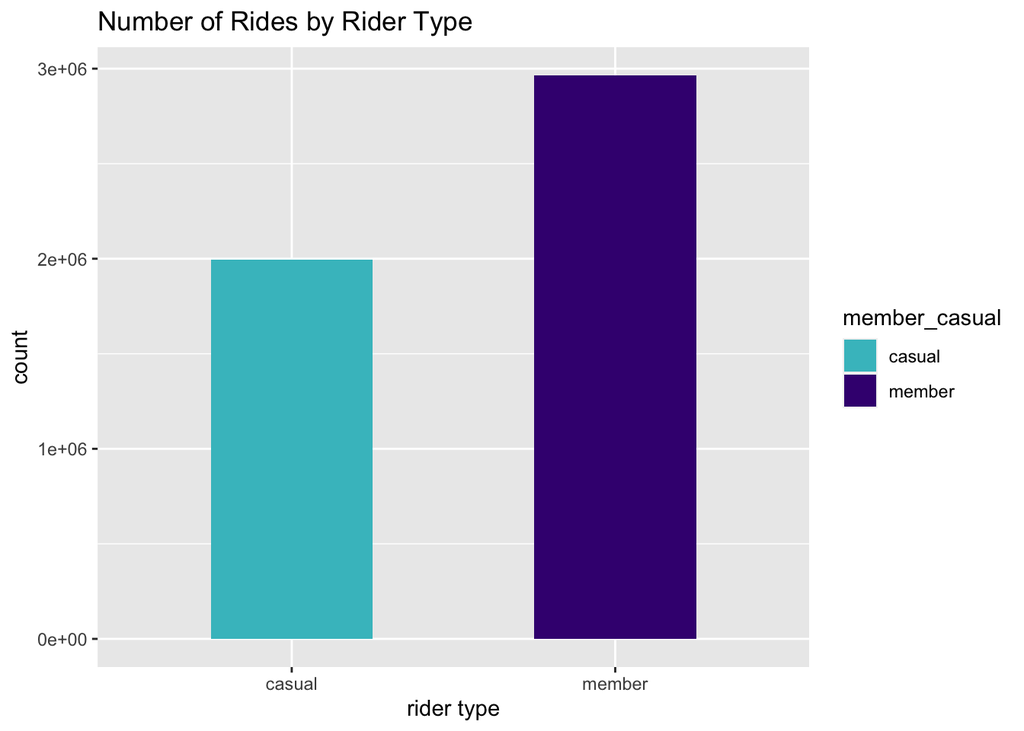

```r
ggplot(data = cyclist_data_2022)+
  (mapping= aes(x=member_casual, fill= member_casual))+
  geom_bar(width = 0.5)+
  labs(title = "Number of Rides by Rider Type", x= "rider type")+
  scale_fill_manual(values = c("casual"="#43BFc7", "member"= "#400080")) # viz for rider type count
```

### How Average Trip Varies Across Different Riders

```r
summary_data<- cyclist_data_2022 %>%
  group_by(member_casual) %>%
  summarize(avg_trip_duration= mean(trip_duration)) # summary data frame to create viz for average trip duration by rider type
```

```
## Defaulting to continuous.
```

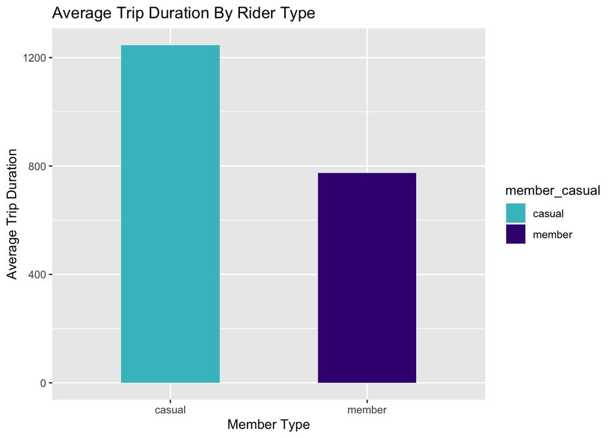

```r
ggplot(data = summary_data, aes(x= member_casual,y= avg_trip_duration, fill= member_casual))+
  geom_bar(stat = "identity", width= 0.5)+
  scale_fill_manual(values = c("casual"="#43BFc7", "member"= "#400080"))+
  labs(title = "Average Trip Duration By Rider Type", x= "Member Type", y= "Average Trip Duration") # viz for average trip duration by rider type
```

### Members Ride Count By Day Of The Week

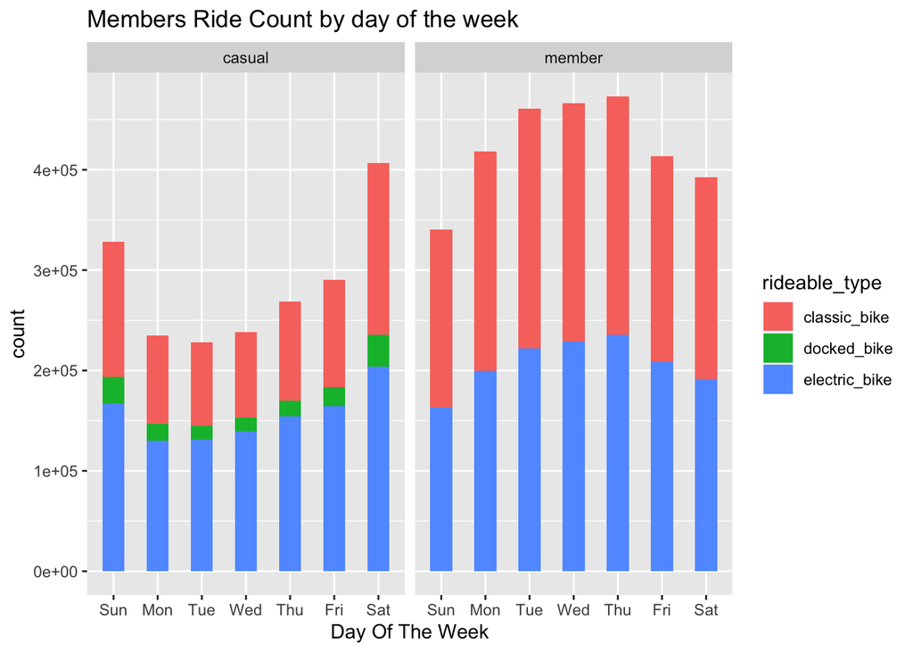

```r
ggplot(data=cyclist_data_2022)+
  (mapping= aes(x= start_day_of_week, fill= rideable_type))+
  geom_bar(width = 0.5)+
  facet_wrap(~member_casual)+
  labs(title= "Members Ride Count by day of the week", x= "Day Of The Week") # viz for members ride count by day of the week
```

[figure not shown]

```r
ggplot(data= summary_by_group_3, aes(x= rideable_type, y= 'mean(trip_duration)', fill= rideable_type))+
  geom_bar(stat = "identity", width= 0.5)+
  scale_fill_manual(values = c("electric_bike" = "#400080", "classic_bike" = "#43bfc7", "docked_bike" = "#a74ac7"))+
  labs(title = "Average Trip Duration By Ride types", x= "Ride Type", y= "Average Trip Duration") # average trip duration by ride type
```

### How Members Use Different Bike Types

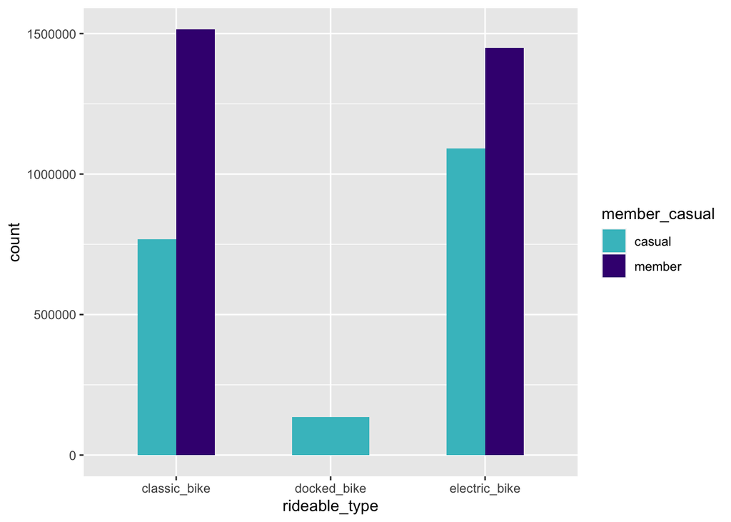

```r
# grouped bar chart

ggplot(data = cyclist_data_2022, aes(x = rideable_type, fill = member_casual)) +
  geom_bar(position = "dodge", stat = "count", width = 0.5)+
  scale_fill_manual(values = c("casual"="#43BFc7", "member"= "#400080")) # change color
```

#### Pecentage Of Bike Type By User Group

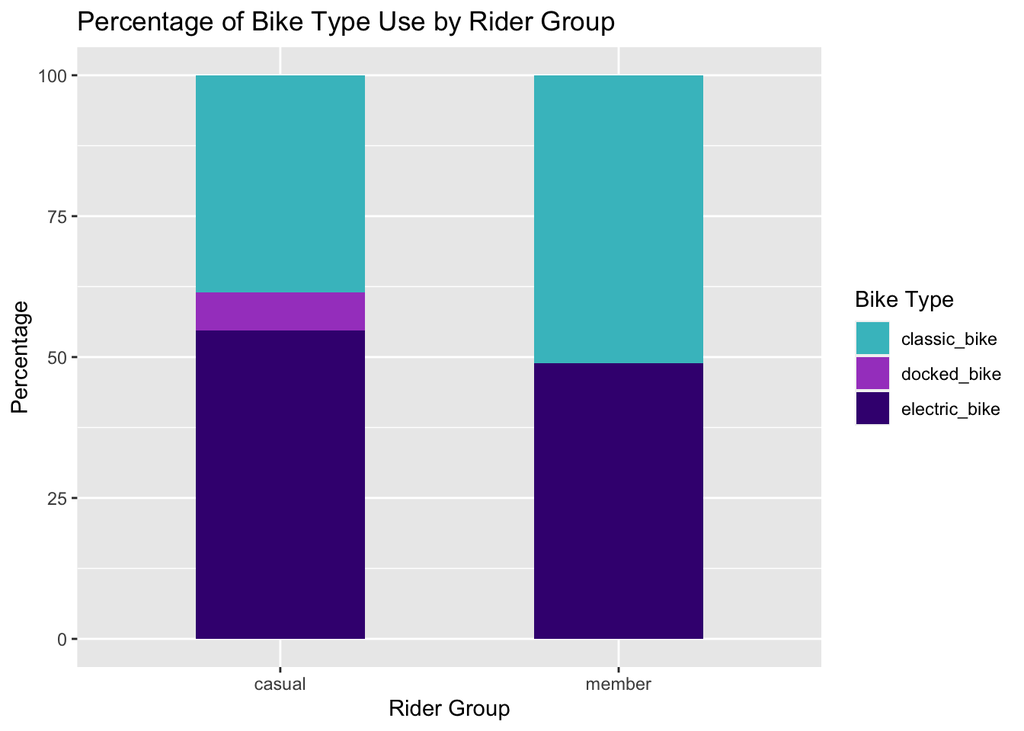

```r
# Calculate the percentage of bike types for casual riders
casual_percent<- cyclist_data_2022 %>%
  filter(member_casual== "casual") %>%
  count(rideable_type) %>%
  mutate(percentage= n/ sum(n)*100)

# Calculate the percentage of bike types for annual members
members_percent<- cyclist_data_2022 %>%
  filter(member_casual== "member") %>%
  count(rideable_type) %>%
  mutate(percentage= n/ sum(n)*100)

# Combine the data for casual riders and annual members
combined_data <- bind_rows(
  data.frame(member_casual = "casual", casual_percent),
  data.frame(member_casual = "member", members_percent)
)

# Create the stacked bar chart
ggplot(data = combined_data, aes(x= member_casual, y= percentage, fill= rideable_type))+
  geom_bar(stat = "identity", width = .5)+
  labs(
    title = "Percentage of Bike Type Use by Rider Group",
    x = "Rider Group",
    y = "Percentage",
    fill = "Bike Type"
  )+
  scale_fill_manual(values = c("electric_bike" = "#400080", "classic_bike" = "#43bfc7", "docked_bike" = "#a74ac7"))
```

### How Docked Bikes Are Used By Day Of The Week

```r
docked_bike_obsv<- cyclist_data_2022 %>%
  filter(rideable_type== "docked_bike" ) # filtering for docked bike
```

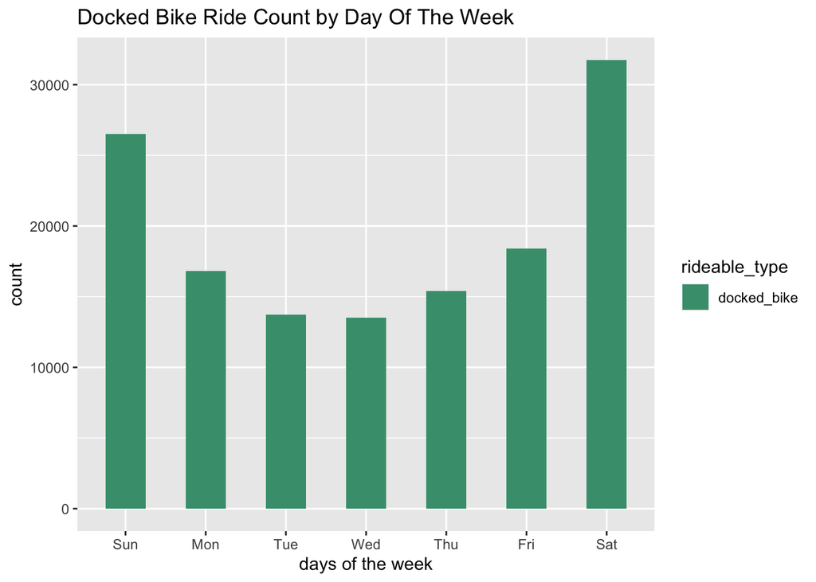

```r
ggplot(data= docked_bike_obsv)+
  (mapping= aes(x= start_day_of_week, fill=rideable_type))+
  geom_bar(width = 0.5)+
  scale_fill_manual(values = c("docked_bike"= "#469d7c"))+
  labs(title="Docked Bike Ride Count by Day Of The Week", x="days of the week")
```

# Key Findings

1. Usage of Docked Bikes: The analysis indicates that annual members do not use docked bikes, while casual members use them with low counts. This suggests that docked bikes may not be appealing to annual members.
2. Trip Duration and Distance: The analysis reveals that docked bikes have the highest mean trip duration and mean trip distance. This could indicate that casual members who use docked bikes tend to take longer rides compared to other ride types.
3. Weekday Usage Patterns: The data suggests that annual members use bikes more frequently on weekdays compared to casual members. This could be because annual members use bikes for commuting or regular transportation purposes.
4. Weekend Usage: The analysis indicates that casual members and annual members have similar frequency of bike usage on weekends. This suggests that weekend leisure activities might be a common motivation for both groups.
5. Casual members have high prefrence for Electric bikes. With electric bike accounting for 54.67% of the total bike ride for casual riders, while Annual members prefer Classic bike with a percentage of 51.1% of total ride attributed to Classic bike.

# Summary

In our analysis of Cyclistic bike usage, we compared the behavior of annual members and casual riders to understand how they differ. We found that annual members showed a significant preference for electric and classic bikes, while completely avoiding the use of docked bikes. On the other hand, casual riders used docked bikes but with a low frequency. Interestingly, docked bikes exhibited the highest mean trip duration and distance.

Furthermore, we observed that annual members utilized bikes more frequently on weekdays, indicating a pattern of commuting or regular usage. In contrast, casual riders and annual members had similar usage frequencies on weekends. These findings suggest that there may be an opportunity to convert casual riders into annual members by enhancing the availability of docked bike stations in strategic locations throughout the city. This could provide convenience and encourage casual riders to choose bikes for their frequent commuting needs, potentially reducing reliance on other modes of transportation.

# Recommended Action

### Product Recommendation

1. Ensure a sufficient supply of electric bikes and classic bikes based on the preferences of different rider groups to enhance customer satisfaction and improve overall ridership.
2. Docked bike stations should be strategically placed along popular commuting routes or near public transportation hubs, to facilitate seamless multi-modal transportation options for both casual members and annual members. This integration with other modes of transportation, such as buses or trains, can make the overall commuting experience more convenient and efficient.

### Marketing recommendations

1. Conduct user surveys or feedback sessions with both casual members and potential annual members to provide valuable insights into their preferences, needs, and expectations regarding docked bike usage. This information can help in making informed decisions about the expansion and placement of docked bike stations to maximize their usage and convenience for both rider groups.
2. Targeted Marketing for Docked Bikes: Develop marketing strategies that highlight the benefits of using docked bikes, such as their reliability, availability, and suitability for longer rides. Tailor these strategies specifically to attract casual members and encourage them to become annual members.
3. Weekday Commuter Programs: Implement commuter-focused programs and incentives to target potential annual members. Emphasize the time-saving, cost-effective, and eco-friendly aspects of using bikes for daily commuting. Consider partnering with local businesses or organizations to provide additional incentives or discounts for annual members who use bikes for commuting.